# R Notebook

## percentages of zero expression genes for each cell in each cell type

```r
zeros.per.cell = colSums(clustered_tpm_LEgenes==0) / nrow(clustered_tpm_LEgenes)
zeros.per.cell[1:2]
```

```
## A10_P3_M11 A11_P1_M11
##  0.8492719  0.8802046
```

```r
ctype = factor(cell_type$type[match(clustered_cells, cell_type$cell)])
zero.percentages = data.table(percentage.zero = zeros.per.cell, grouping = ctype)
rownames(zero.percentages) = names(zeros.per.cell)
dim(zero.percentages)
```

```
## [1] 14743     2
```

```r
head(zero.percentages)
```

| percentage.zero | grouping |
| --- | --- |
| 0.8492719 | NK2 |
| 0.8802046 | NK2 |
| 0.8794963 | NK2 |
| 0.7811098 | Tregs |
| 0.9094845 | NK2 |
| 0.7946478 | NK3 |

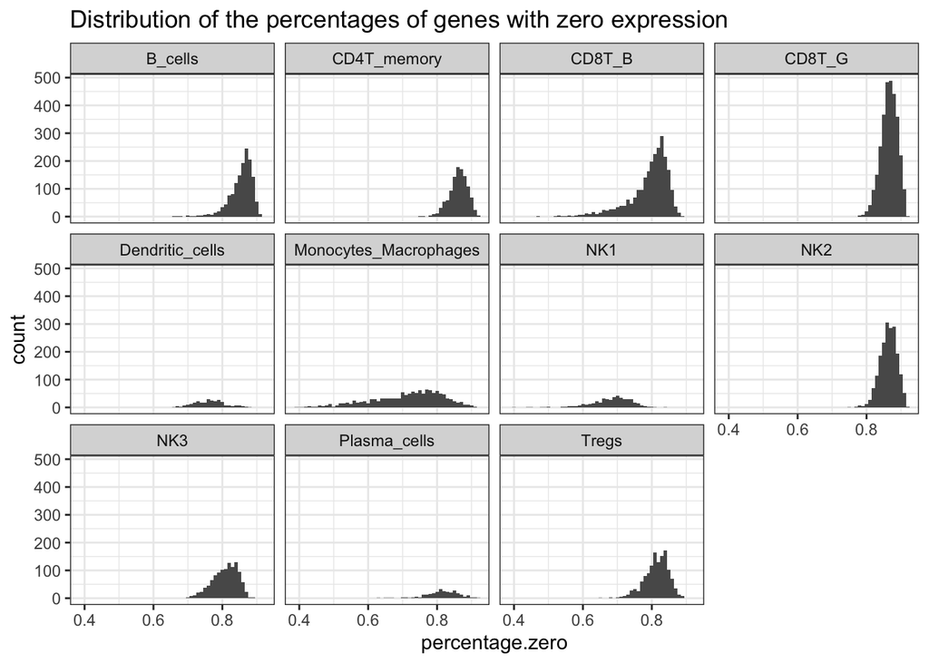

```r
# distribution of the percentages of zero expression genes for cells by cell type
ggplot(data = zero.percentages) +
  geom_histogram(aes(x=percentage.zero), binwidth = 0.01) +
  facet_wrap(~grouping) +
  ggtitle("Distribution of the percentages of genes with zero expression")
```

```r
zero.percentages[, .(.N), by = .(grouping)]
```

| grouping | N |
| --- | --- |
| NK2 | 1904 |
| Tregs | 1313 |
| NK3 | 1146 |
| CD8T_G | 3033 |
| CD8T_B | 2458 |
| Dendritic_cells | 275 |
| CD4T_memory | 1099 |
| Monocytes_Macrophages | 1341 |
| NK1 | 463 |
| Plasma_cells | 290 |

[output cut: 1 more lines]

```r
z2 = zero.percentages[, .(qs=list(quantile(percentage.zero))),
                 by = .(grouping)]
print(z2)
```

```
##                  grouping                                                qs
##  1:                   NK2 0.7452184,0.8476978,0.8645415,0.8807556,0.9238095
##  2:                 Tregs 0.6525777,0.7932310,0.8170799,0.8391185,0.8927981
##  3:                   NK3 0.6965762,0.7841007,0.8132231,0.8375443,0.8916962
##  4:                CD8T_G 0.7765447,0.8503739,0.8670602,0.8829595,0.9161747
##  5:                CD8T_B 0.4697363,0.7688705,0.8077135,0.8312475,0.8860291
##  6:       Dendritic_cells 0.6597403,0.7287682,0.7619835,0.7907517,0.8772924
##  7:           CD4T_memory 0.7517513,0.8461236,0.8632822,0.8792601,0.9163322
##  8: Monocytes_Macrophages 0.3922078,0.6466745,0.7315230,0.7891381,0.9118457
##  9:                   NK1 0.4010232,0.6537584,0.6915388,0.7237702,0.8393546
## 10:          Plasma_cells 0.6342385,0.7905155,0.8169618,0.8480126,0.9160173
## 11:               B_cells 0.6573003,0.8397481,0.8613932,0.8772137,0.9127902
```

```r
rm(zeros.per.cell)
```

Based on the graph, the spread of distribution of the percentages of zero expression genes is quite different for each cell type, here we try to select 200 cells with the smallest percentages of zero expression genes.

```r
fewzero_cells = unname(unlist(by(zero.percentages, zero.percentages$grouping,
                                 FUN = function(x) rownames(x)[order(x$percentage.zero)][1:200])))
fewzero_cells[1:3]
```

```
## [1] "E4_P4_M47" "E5_P4_M47" "C9_P1_M47"
```

## LM22 signature matrix

- select genes that appear both in the LM22 signature matrix and the SF data
- in those genes, further select genes that have expression in a relatively large amount of cells

```r
CBST_LM22 = read.table("../../_reference/LM22.txt", sep = "\t", header = TRUE, as.is = TRUE)
dim(CBST_LM22)
```

```
## [1] 547  23
```

```r
CBST_LM22[1:2,]
```

|  | Gene.symbol | B.cells.naive | B.cells.memory | Plasma.cells | T.cells.CD8 | T.cells.CD4.naive | T.cells.CD4.memory.resting | T.cells.CD4.memory.activated | T.cells.follicular.helper | T.cells.regulatory..Tregs. | T.cells.gamma.delta | NK.cells.resting | NK.cells.activated | Monocytes | Macrophages.M0 | Macrophages.M1 | Macrophages.M2 | Dendritic.cells.resting | Dendritic.cells.activated | Mast.cells.resting | Mast.cells.activated | Eosinophils | Neutrophils |
| --- | --- | --- | --- | --- | --- | --- | --- | --- | --- | --- | --- | --- | --- | --- | --- | --- | --- | --- | --- | --- | --- | --- | --- |
| 1 | ABCB4 | 555.71345 | 10.74423 | 7.225819 | 4.31128 | 4.60586 | 7.406442 | 8.043976 | 6.469993 | 7.833082 | 9.312295 | 13.68284 | 4.556713 | 6.202496 | 7.95136 | 27.55771 | 121.43228 | 114.6367 | 4.872184 | 4.727985 | 34.11366 | 15.03053 | 14.90689 |
| 2 | ABCB9 | 15.60354 | 22.09479 | 653.392328 | 24.22372 | 35.67151 | 30.048192 | 38.455423 | 17.604795 | 46.073657 | 19.715722 | 21.86372 | 16.396143 | 20.309426 | 56.25189 | 29.38088 | 40.39026 | 123.9933 | 23.384603 | 53.466757 | 23.61575 | 29.78644 | 33.67915 |

```r
# 538 out of 547
CBST.SFgenes = CBST_LM22$Gene.symbol[CBST_LM22$Gene.symbol %in% gene.names]
length(CBST.SFgenes)
```

```
## [1] 538
```

```r
# 323 out of 538
CBST.largeExpression.genes = intersect(CBST.SFgenes, large.express.genes.all)
length(CBST.largeExpression.genes)
```

```
## [1] 323
```

```r
# 323 x 23
CBST_SFLEgenes_LM22 = CBST_LM22[match(CBST.largeExpression.genes, CBST_LM22$Gene.symbol),]

dim(CBST_SFLEgenes_LM22)
```

```
## [1] 323  23
```

```r
CBST_SFLEgenes_LM22[1:2,]
```

|  | Gene.symbol | B.cells.naive | B.cells.memory | Plasma.cells | T.cells.CD8 | T.cells.CD4.naive | T.cells.CD4.memory.resting | T.cells.CD4.memory.activated | T.cells.follicular.helper | T.cells.regulatory..Tregs. | T.cells.gamma.delta | NK.cells.resting | NK.cells.activated | Monocytes | Macrophages.M0 | Macrophages.M1 | Macrophages.M2 | Dendritic.cells.resting | Dendritic.cells.activated | Mast.cells.resting | Mast.cells.activated | Eosinophils | Neutrophils |
| --- | --- | --- | --- | --- | --- | --- | --- | --- | --- | --- | --- | --- | --- | --- | --- | --- | --- | --- | --- | --- | --- | --- | --- |
| 3 | ACAP1 | 215.3060 | 321.621 | 38.61687 | 1055.6134 | 1790.0972 | 922.1527 | 340.8834 | 1107.7983 | 1995.483 | 280.0757 | 512.6369 | 387.5817 | 190.8790 | 48.97222 | 30.97425 | 23.05515 | 61.38655 | 26.41292 | 104.2002 | 73.60793 | 696.4428 | 596.0260 |
| 5 | ACP5 | 605.8974 | 1935.201 | 1120.10468 | 306.3125 | 744.6566 | 557.8198 | 248.5469 | 711.9497 | 958.916 | 493.9691 | 340.8201 | 239.2771 | 512.9314 | 13644.17230 | 1062.47591 | 7633.96018 | 13825.05363 | 3989.86517 | 263.4979 | 323.38128 | 860.5634 | 307.1428 |

# Compare the correlation of cell types

- Compare the correlation between our 11 cell types.
- Compare the correlation between the cell types in the LM22 vs. the 11 cell types we had.
- Two types of correlation: using all cells for each cell type to calculate mean gene expression, or calculate the mean expression using 200 cells with smallest percentages of zero expression genes.

## Correlations between our 11 cell types

### using mean expression of filtered genes shared between SF data and LM22 matrix

```r
table(rownames(clustered_tpm_LEgenes) == large.express.genes.all)
```

```
##
##  TRUE
## 12705
```

```r
match1 = match(CBST.largeExpression.genes, large.express.genes.all)
LEgenes_CBST_tpm = as.data.table(t(clustered_tpm_LEgenes[match1,]))

rownames(LEgenes_CBST_tpm) = clustered_cells
colnames(LEgenes_CBST_tpm) = CBST.largeExpression.genes
dim(LEgenes_CBST_tpm)
```

```
## [1] 14743   323
```

```r
LEgenes_CBST_tpm[1:5,1:5]
```

| ACAP1 | ACP5 | ADAM28 | ADRB2 | AIF1 |
| --- | --- | --- | --- | --- |
| 0.00 | 0.00 | 0 | 0 | 0 |
| 0.00 | 9.71 | 0 | 0 | 0 |
| 10.09 | 9.45 | 0 | 0 | 0 |
| 8.03 | 8.76 | 0 | 0 | 0 |
| 10.26 | 0.00 | 0 | 0 | 0 |

```r
LEgenes_CBST_tpm$grouping = factor(cell_type$type[match(clustered_cells, cell_type$cell)])
table(LEgenes_CBST_tpm$grouping)
```

```
##
##               B_cells           CD4T_memory                CD8T_B
##                  1421                  1099                  2458
##                CD8T_G       Dendritic_cells Monocytes_Macrophages
##                  3033                   275                  1341
##                   NK1                   NK2                   NK3
##                   463                  1904                  1146
##          Plasma_cells                 Tregs
##                   290                  1313
```

```r
cmean = LEgenes_CBST_tpm[, lapply(.SD, mean), by = grouping]
cmed  = LEgenes_CBST_tpm[, lapply(.SD, median), by = grouping]
csd   = LEgenes_CBST_tpm[, lapply(.SD, sd), by = grouping]

dim(cmean)
```

```
## [1]  11 324
```

```r
cmean[1:2,1:5]
```

| grouping | ACAP1 | ACP5 | ADAM28 | ADRB2 |
| --- | --- | --- | --- | --- |
| NK2 | 4.118918 | 0.8984664 | 0.2400525 | 1.3751576 |
| Tregs | 4.912437 | 2.7483168 | 0.1575019 | 0.1061386 |

```r
dim(cmed)
```

```
## [1]  11 324
```

```r
cmed[1:2,1:5]
```

| grouping | ACAP1 | ACP5 | ADAM28 | ADRB2 |
| --- | --- | --- | --- | --- |
| NK2 | 0.00 | 0 | 0 | 0 |
| Tregs | 7.26 | 0 | 0 | 0 |

```r
dim(csd)
```

```
## [1]  11 324
```

```r
csd[1:2,1:5]
```

| grouping | ACAP1 | ACP5 | ADAM28 | ADRB2 |
| --- | --- | --- | --- | --- |
| NK2 | 4.432388 | 2.670594 | 1.324334 | 3.2018348 |
| Tregs | 4.273537 | 4.068013 | 1.028861 | 0.9256457 |

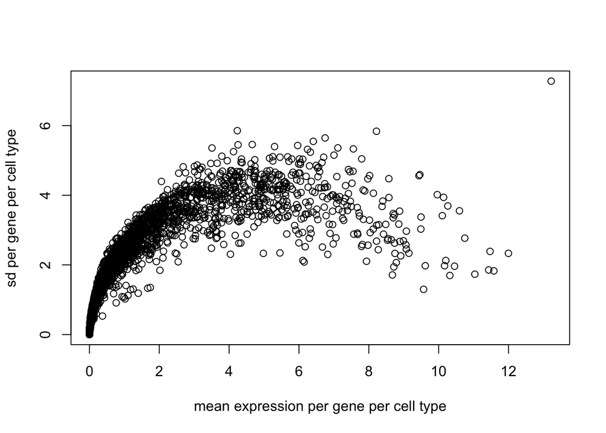

```r
plot(as.numeric(unlist(cmean[,-1])), as.numeric(unlist(csd[,-1])),
     xlab="mean expression per gene per cell type",
     ylab="sd per gene per cell type")
```

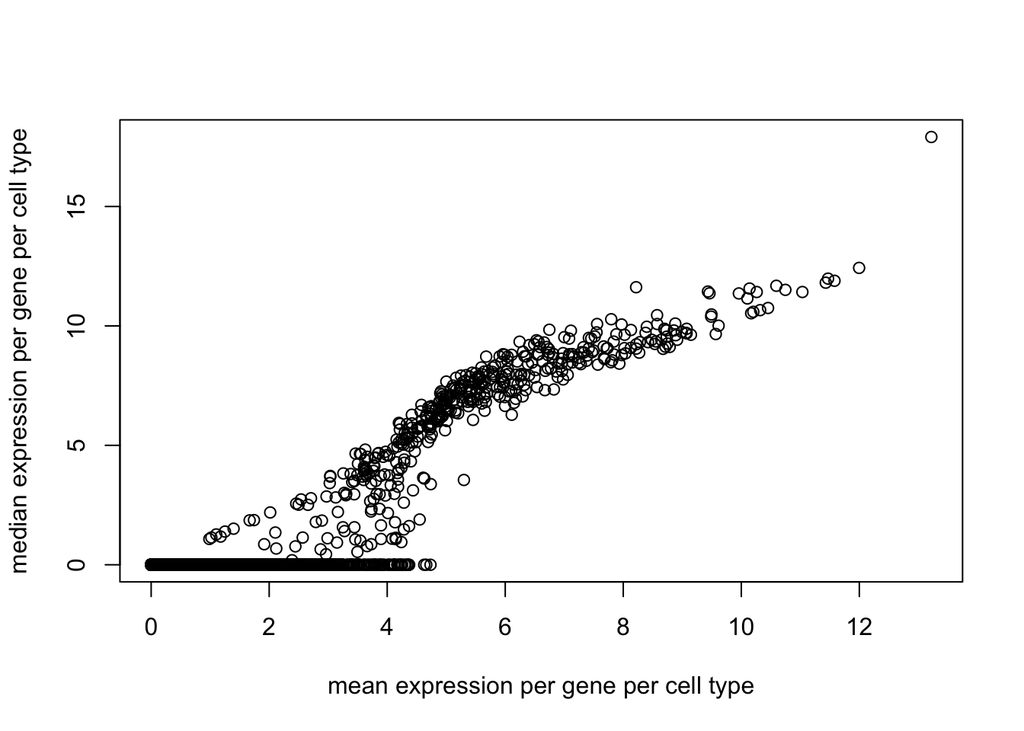

```r
plot(as.numeric(unlist(cmean[,-1])), as.numeric(unlist(cmed[,-1])),
     xlab="mean expression per gene per cell type",
     ylab="median expression per gene per cell type")
```

```r
LEgene_CBST_expression = LEgenes_CBST_tpm[, lapply(.SD, mean), by = grouping] # 11 x 324
LEgene_CBST_expression = LEgene_CBST_expression[order(LEgene_CBST_expression$grouping),]
LEgene_CBST_expression[,1:6]
```

| grouping | ACAP1 | ACP5 | ADAM28 | ADRB2 | AIF1 |
| --- | --- | --- | --- | --- | --- |
| B_cells | 3.938494 | 2.5605278 | 5.96448980 | 0.5446446 | 0.11483462 |
| CD4T_memory | 4.239227 | 0.7993176 | 0.05380346 | 0.3662056 | 0.26013649 |
| CD8T_B | 5.617705 | 3.1197722 | 0.27908055 | 0.4917413 | 0.60178600 |
| CD8T_G | 4.370762 | 0.9467656 | 0.18363996 | 1.1035180 | 0.20554896 |
| Dendritic_cells | 3.459600 | 1.7877091 | 0.63250909 | 0.7040727 | 1.93189091 |
| Monocytes_Macrophages | 1.378844 | 3.7712975 | 2.13219985 | 1.1013647 | 8.91285608 |
| NK1 | 5.133024 | 2.5581857 | 0.28879050 | 0.4654212 | 0.97323974 |
| NK2 | 4.118918 | 0.8984664 | 0.24005252 | 1.3751576 | 0.12666492 |
| NK3 | 5.276457 | 2.9709599 | 0.45558464 | 0.5936824 | 0.46397906 |
| Plasma_cells | 1.605000 | 1.0099310 | 1.91906897 | 0.5064828 | 0.05617241 |

[output cut: 1 more lines]

```r
LEgene_CBST_compare_expression = as.data.frame(t(LEgene_CBST_expression[,-1]))
colnames(LEgene_CBST_compare_expression) = LEgene_CBST_expression$grouping
head(LEgene_CBST_compare_expression)
```

|  | B_cells | CD4T_memory | CD8T_B | CD8T_G | Dendritic_cells | Monocytes_Macrophages | NK1 | NK2 | NK3 | Plasma_cells | Tregs |
| --- | --- | --- | --- | --- | --- | --- | --- | --- | --- | --- | --- |
| ACAP1 | 3.9384940 | 4.23922657 | 5.6177055 | 4.3707616 | 3.45960000 | 1.3788441 | 5.1330238 | 4.1189181 | 5.2764572 | 1.60500000 | 4.91243717 |
| ACP5 | 2.5605278 | 0.79931756 | 3.1197722 | 0.9467656 | 1.78770909 | 3.7712975 | 2.5581857 | 0.8984664 | 2.9709599 | 1.00993103 | 2.74831683 |
| ADAM28 | 5.9644898 | 0.05380346 | 0.2790806 | 0.1836400 | 0.63250909 | 2.1321999 | 0.2887905 | 0.2400525 | 0.4555846 | 1.91906897 | 0.15750190 |
| ADRB2 | 0.5446446 | 0.36620564 | 0.4917413 | 1.1035180 | 0.70407273 | 1.1013647 | 0.4654212 | 1.3751576 | 0.5936824 | 0.50648276 | 0.10613861 |
| AIF1 | 0.1148346 | 0.26013649 | 0.6017860 | 0.2055490 | 1.93189091 | 8.9128561 | 0.9732397 | 0.1266649 | 0.4639791 | 0.05617241 | 0.08766946 |
| AIM2 | 1.1823153 | 0.25707916 | 0.7327950 | 0.4492779 | 0.02654545 | 0.6359881 | 1.0527862 | 0.3143697 | 0.4610297 | 0.85382759 | 0.71645849 |

```r
rm(LEgene_CBST_expression)
rm(LEgenes_CBST_tpm)
```

The patterns of the correlation roughly match our expectation: - Plasma cells, Monocytes/Macrophages, Dendritic cells and B cells do no have major correlation with other cell types, matches the clustering result that these 4 cell types form most distinct clusters - The 3 NK cell clusters are closely related with each other - CD8 cells, NK cells, and CD4 T cells are closely related

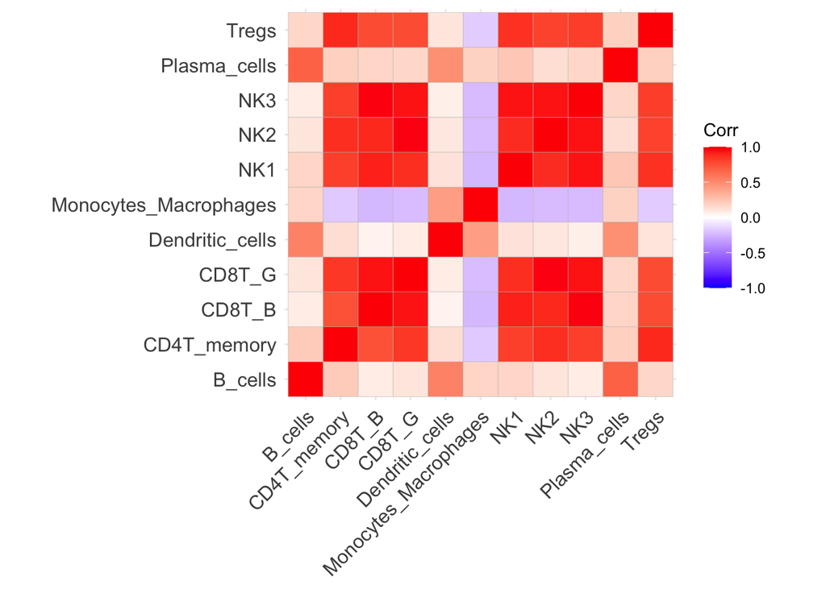

```r
cormat_LE.CBSTgenes_11type = cor(LEgene_CBST_compare_expression, method = "spearman")
ggcorrplot(cormat_LE.CBSTgenes_11type)
```

### using mean expression for filtered genes shared between SF data and LM22 matrix over the cells with fewer zero gene expression

```r
match1 = match(CBST.largeExpression.genes, large.express.genes.all)
LEgenes_CBST_few0_tpm = as.data.table(t(clustered_tpm_LEgenes[match1, ..fewzero_cells]))
rownames(LEgenes_CBST_few0_tpm) = fewzero_cells
colnames(LEgenes_CBST_few0_tpm) = CBST.largeExpression.genes

LEgenes_CBST_few0_tpm[1:5,1:5]
```

| ACAP1 | ACP5 | ADAM28 | ADRB2 | AIF1 |
| --- | --- | --- | --- | --- |
| 7.95 | 0.00 | 5.63 | 0 | 0.00 |
| 5.30 | 6.67 | 5.60 | 0 | 0.00 |
| 6.81 | 8.12 | 4.17 | 0 | 0.00 |
| 0.00 | 1.11 | 0.00 | 0 | 0.00 |
| 4.13 | 10.15 | 6.66 | 0 | 5.87 |

```r
LEgenes_CBST_few0_tpm$grouping = factor(cell_type$type[match(fewzero_cells, cell_type$cell)])
table(LEgenes_CBST_few0_tpm$grouping)
```

```
##
##               B_cells           CD4T_memory                CD8T_B
##                   200                   200                   200
##                CD8T_G       Dendritic_cells Monocytes_Macrophages
##                   200                   200                   200
##                   NK1                   NK2                   NK3
##                   200                   200                   200
##          Plasma_cells                 Tregs
##                   200                   200
```

```r
LEgene_CBST_few0_expression = LEgenes_CBST_few0_tpm[, lapply(.SD, mean), by = grouping] # 11 x 324
LEgene_CBST_few0_expression[,1:6]
```

| grouping | ACAP1 | ACP5 | ADAM28 | ADRB2 | AIF1 |
| --- | --- | --- | --- | --- | --- |
| B_cells | 4.69130 | 3.90685 | 6.06235 | 0.42835 | 0.25155 |
| CD4T_memory | 4.83655 | 1.26750 | 0.11085 | 0.47240 | 0.43065 |
| CD8T_B | 5.68115 | 2.77350 | 0.06740 | 0.51700 | 1.48270 |
| CD8T_G | 5.01610 | 0.96740 | 0.14280 | 1.22630 | 0.35560 |
| Dendritic_cells | 3.88825 | 2.09360 | 0.66055 | 0.66470 | 2.18130 |
| Monocytes_Macrophages | 1.31675 | 4.43120 | 2.74115 | 1.84865 | 9.39235 |
| NK1 | 5.66915 | 2.78810 | 0.36110 | 0.33445 | 1.68510 |
| NK2 | 5.08510 | 0.97165 | 0.35030 | 1.71980 | 0.41375 |
| NK3 | 6.36010 | 3.57895 | 0.59265 | 0.26050 | 1.01755 |
| Plasma_cells | 1.57670 | 1.21400 | 1.93450 | 0.55690 | 0.05095 |

[output cut: 1 more lines]

```r
LEgene_CBST_few0_compare_expression = as.data.frame(t(LEgene_CBST_few0_expression[,-1]))
colnames(LEgene_CBST_few0_compare_expression) = LEgene_CBST_few0_expression$grouping
head(LEgene_CBST_few0_compare_expression)
```

|  | B_cells | CD4T_memory | CD8T_B | CD8T_G | Dendritic_cells | Monocytes_Macrophages | NK1 | NK2 | NK3 | Plasma_cells | Tregs |
| --- | --- | --- | --- | --- | --- | --- | --- | --- | --- | --- | --- |
| ACAP1 | 4.69130 | 4.83655 | 5.68115 | 5.0161 | 3.88825 | 1.31675 | 5.66915 | 5.08510 | 6.36010 | 1.57670 | 5.86215 |
| ACP5 | 3.90685 | 1.26750 | 2.77350 | 0.9674 | 2.09360 | 4.43120 | 2.78810 | 0.97165 | 3.57895 | 1.21400 | 3.53735 |
| ADAM28 | 6.06235 | 0.11085 | 0.06740 | 0.1428 | 0.66055 | 2.74115 | 0.36110 | 0.35030 | 0.59265 | 1.93450 | 0.17185 |
| ADRB2 | 0.42835 | 0.47240 | 0.51700 | 1.2263 | 0.66470 | 1.84865 | 0.33445 | 1.71980 | 0.26050 | 0.55690 | 0.15330 |
| AIF1 | 0.25155 | 0.43065 | 1.48270 | 0.3556 | 2.18130 | 9.39235 | 1.68510 | 0.41375 | 1.01755 | 0.05095 | 0.19170 |
| AIM2 | 2.06855 | 0.56195 | 1.68995 | 0.6669 | 0.01830 | 1.08310 | 1.02535 | 0.47745 | 0.84430 | 0.96915 | 0.72500 |

```r
rm(LEgene_CBST_few0_expression)
rm(LEgenes_CBST_few0_tpm)
```

The result using cells with fewer zero expression genes is not very different from the result using all cells.

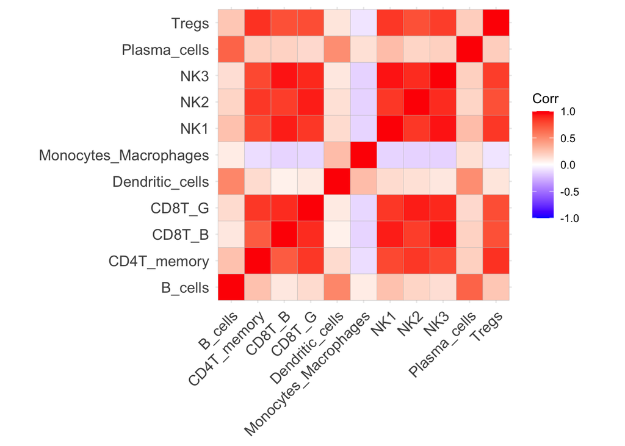

```r
cormat_LE.CBST.few0genes_11type = cor(LEgene_CBST_few0_compare_expression, method = "spearman")
ggcorrplot(cormat_LE.CBST.few0genes_11type)
```

## Correlations between our 11 cell types and the cell types in the LM22 matrix

### using mean expression of filtered genes shared between SF data and LM22 matrix

```r
cormat_LM22_11type = cor(CBST_SFLEgenes_LM22[,-1], LEgene_CBST_compare_expression,
                         method = "spearman")
dim(cormat_LM22_11type)
```

```
## [1] 22 11
```

```r
cormat_LM22_11type[1:2,1:3]
```

```
##                  B_cells CD4T_memory     CD8T_B
## B.cells.naive  0.5721863  0.07737999 0.02278787
## B.cells.memory 0.6458689  0.11158865 0.06203685
```

```r
range(c(cormat_LM22_11type))
```

```
## [1] -0.3007698  0.7728268
```

The correlations between our 11 cell types and the cell types in the LM22 matrix still have some unexpected patterns

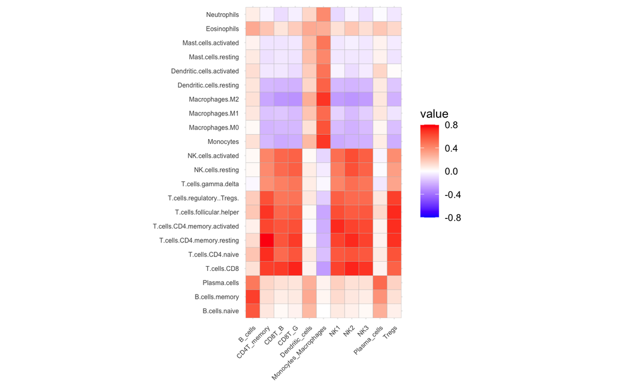

```r
p = ggcorrplot(t(cormat_LM22_11type), tl.cex = 6)
p + scale_fill_gradient2(limit = c(-0.8,0.8), low = "blue", high =  "red",
                         mid = "white", midpoint = 0)
```

### using mean expression for filtered genes shared between SF data and LM22 matrix over cells with fewer zero gene expression

```r
cormat_LM22_11type_few0 = cor(CBST_SFLEgenes_LM22[,-1],
                              LEgene_CBST_few0_compare_expression,
                         method = "spearman")
dim(cormat_LM22_11type_few0)
```

```
## [1] 22 11
```

```r
cormat_LM22_11type_few0[1:2,1:3]
```

```
##                  B_cells CD4T_memory       CD8T_B
## B.cells.naive  0.5634878  0.06669643 -0.005526068
## B.cells.memory 0.6410933  0.10909850  0.040066676
```

```r
range(c(cormat_LM22_11type_few0))
```

```
## [1] -0.2752991  0.7577759
```

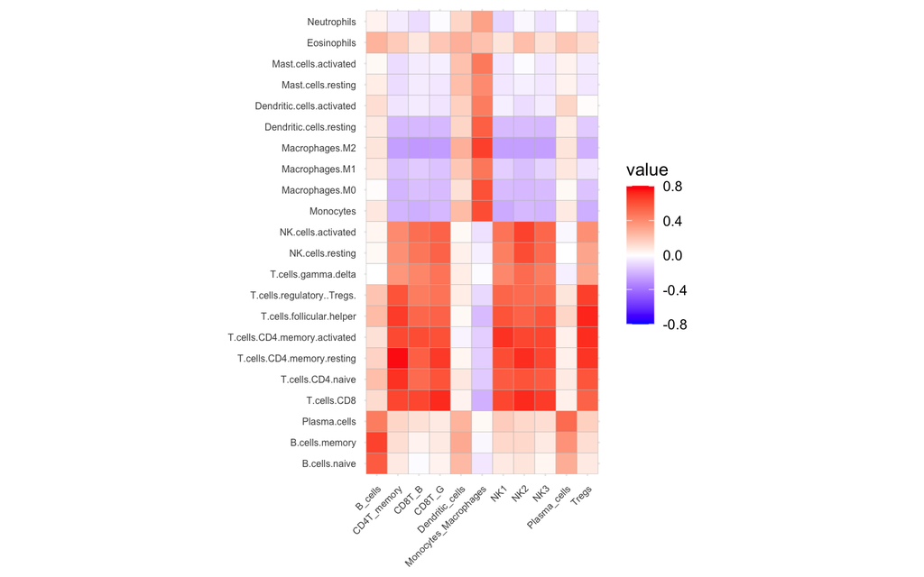

```r
p = ggcorrplot(t(cormat_LM22_11type_few0), tl.cex = 6)
p + scale_fill_gradient2(limit = c(-0.8,0.8), low = "blue", high =  "red",
                         mid = "white", midpoint = 0)
```

## Compare the scatterplot of gene expressions between LM22 cell types and our cell types

### B cells and B cells

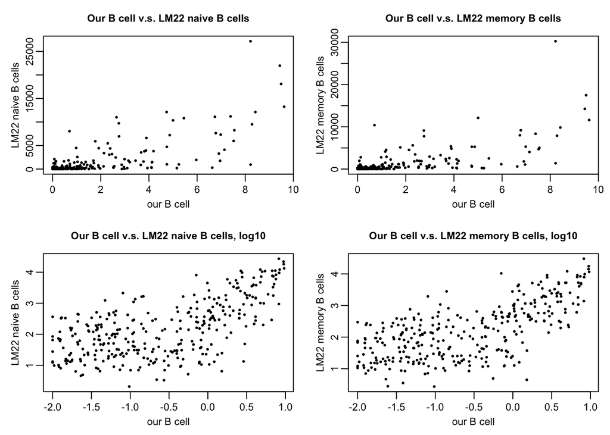

```r
par(mar=c(3,3,2.5,0.8), mgp=c(1.5,0.5,0), cex.axis=0.85, cex.lab=0.85, cex.main=0.85)
layout(matrix(c(1,2,3,4),nrow=2,ncol = 2,byrow = TRUE))

plot(as.numeric(LEgene_CBST_compare_expression$`B_cells`),
               as.numeric(CBST_SFLEgenes_LM22$B.cells.naive),
               main = "Our B cell v.s. LM22 naive B cells",
               xlab = "our B cell", ylab = "LM22 naive B cells",
               pch=20, cex = 0.5)

plot(as.numeric(LEgene_CBST_compare_expression$`B_cells`),
               as.numeric(CBST_SFLEgenes_LM22$B.cells.memory),
               main = "Our B cell v.s. LM22 memory B cells",
               xlab = "our B cell", ylab = "LM22 memory B cells",
               pch=20, cex = 0.5)

plot(log10(as.numeric(LEgene_CBST_compare_expression$`B_cells`) + 0.01),
               log10(as.numeric(CBST_SFLEgenes_LM22$B.cells.naive) + 0.01),
               main = "Our B cell v.s. LM22 naive B cells, log10",
               xlab = "our B cell", ylab = "LM22 naive B cells",
               pch=20, cex = 0.5)

plot(log10(as.numeric(LEgene_CBST_compare_expression$`B_cells`) + 0.01),
               log10(as.numeric(CBST_SFLEgenes_LM22$B.cells.memory) + 0.01),
               main = "Our B cell v.s. LM22 memory B cells, log10",
               xlab = "our B cell", ylab = "LM22 memory B cells",
               pch=20, cex = 0.5)
```

### CD8 cells and CD8 cells

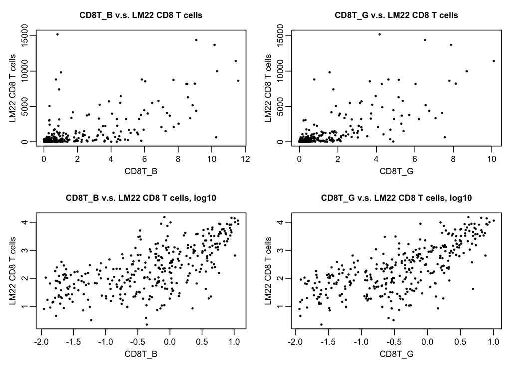

```r
par(mar=c(3,3,2.5,0.8), mgp=c(1.5,0.5,0), cex.axis=0.85, cex.lab=0.85, cex.main=0.85)
layout(matrix(c(1,2,3,4),nrow=2,ncol = 2,byrow = TRUE))


plot(as.numeric(LEgene_CBST_compare_expression$`CD8T_B`),
               as.numeric(CBST_SFLEgenes_LM22$T.cells.CD8),
               main = "CD8T_B v.s. LM22 CD8 T cells",
               xlab = "CD8T_B", ylab = "LM22 CD8 T cells",
               pch=20, cex = 0.5)

plot(as.numeric(LEgene_CBST_compare_expression$`CD8T_G`),
               as.numeric(CBST_SFLEgenes_LM22$T.cells.CD8),
               main = "CD8T_G v.s. LM22 CD8 T cells",
               xlab = "CD8T_G", ylab = "LM22 CD8 T cells",
               pch=20, cex = 0.5)

plot(log10(as.numeric(LEgene_CBST_compare_expression$`CD8T_B`) + 0.01),
               log10(as.numeric(CBST_SFLEgenes_LM22$T.cells.CD8) + 0.01),
               main = "CD8T_B v.s. LM22 CD8 T cells, log10",
               xlab = "CD8T_B", ylab = "LM22 CD8 T cells",
               pch=20, cex = 0.5)

plot(log10(as.numeric(LEgene_CBST_compare_expression$`CD8T_G`) + 0.01),
               log10(as.numeric(CBST_SFLEgenes_LM22$T.cells.CD8) + 0.01),
               main = "CD8T_G v.s. LM22 CD8 T cells, log10",
               xlab = "CD8T_G", ylab = "LM22 CD8 T cells",
               pch=20, cex = 0.5)
```

```r
gc()
```

```
##             used   (Mb) gc trigger   (Mb) limit (Mb)   max used    (Mb)
## Ncells   1105621   59.1    1904248  101.7         NA    1904248   101.7
## Vcells 280242963 2138.1 1090480651 8319.8      32768 1957513754 14934.7
```